# HW6 Brinda Murulidhara

Final Project Draft

Brinda Murulidhara  
2022-01-21

## Read in a dataset

I have chosen the Emergency - 911 calls dataset from Kaggle (https://www.kaggle.com/mchirico/montcoalert/version/32) for my final project. The dataset contains emergency 911 calls in Montgomery County, Pennsylvania from 2015 to 2020. Below is the code snippet to read and preview the data.

```r
library(dplyr)
emergency_calls_data <- read.csv("911.csv")
head(emergency_calls_data)
```

```
       lat       lng
1 40.29788 -75.58129
2 40.25806 -75.26468
3 40.12118 -75.35198
4 40.11615 -75.34351
5 40.25149 -75.60335
6 40.25347 -75.28324
                                                                                 desc
1           REINDEER CT & DEAD END;  NEW HANOVER; Station 332; 2015-12-10 @ 17:10:52;
2 BRIAR PATH & WHITEMARSH LN;  HATFIELD TOWNSHIP; Station 345; 2015-12-10 @ 17:29:21;
3                          HAWS AVE; NORRISTOWN; 2015-12-10 @ 14:39:21-Station:STA27;
4               AIRY ST & SWEDE ST;  NORRISTOWN; Station 308A; 2015-12-10 @ 16:47:36;
5    CHERRYWOOD CT & DEAD END;  LOWER POTTSGROVE; Station 329; 2015-12-10 @ 16:56:52;
6               CANNON AVE & W 9TH ST;  LANSDALE; Station 345; 2015-12-10 @ 15:39:04;
    zip                   title           timeStamp               twp
1 19525  EMS: BACK PAINS/INJURY 2015-12-10 17:10:52       NEW HANOVER
2 19446 EMS: DIABETIC EMERGENCY 2015-12-10 17:29:21 HATFIELD TOWNSHIP
3 19401     Fire: GAS-ODOR/LEAK 2015-12-10 14:39:21        NORRISTOWN
4 19401  EMS: CARDIAC EMERGENCY 2015-12-10 16:47:36        NORRISTOWN
5    NA          EMS: DIZZINESS 2015-12-10 16:56:52  LOWER POTTSGROVE
6 19446        EMS: HEAD INJURY 2015-12-10 15:39:04          LANSDALE
                        addr e
1     REINDEER CT & DEAD END 1
2 BRIAR PATH & WHITEMARSH LN 1
3                   HAWS AVE 1
4         AIRY ST & SWEDE ST 1
5   CHERRYWOOD CT & DEAD END 1
6      CANNON AVE & W 9TH ST 1
```

## Variables in the dataset

Below are the variables in the dataset:

1. lat: Latitude of the location where the emergency occurred. The data type is double.
2. lng: Longitude of the location where the emergency occurred. The data type is double.
3. desc: Description of the emergency. The data type is String.
4. zip: Zipcode of the location where the emergency occurred. The data type is integer. This variable is interpreted as a factor.
5. title: Type of emergency. The data type is String.
6. timeStamp: Date and time of the emergency call. The data type is String.
7. twp: Township where the emergency occurred. The data type is String.
8. addr: Address of the emergency location. The data type is String.
9. e: Index column whose value is always 1. The data type is integer.

## Descriptive statistics

### Mean

Below are the means of latitude and longitude columns.

```r
summarise(emergency_calls_data, mean_latitude=mean(lat), mean_longitude=mean(lng))
```

```
  mean_latitude mean_longitude
1      40.15816       -75.3001
```

### Median

Below are the medians of latitude and longitude columns.

```r
summarise(emergency_calls_data, median_latitude=median(lat), median_longitude=median(lng))
```

```
  median_latitude median_longitude
1        40.14393        -75.30514
```

### Standard Deviation

Below are the standard deviations of latitude and longitude columns.

```r
summarise(emergency_calls_data, sd_latitude=sd(lat), sd_longitude=sd(lng))
```

```
  sd_latitude sd_longitude
1   0.2206414     1.672884
```

### Frequencies

Below are the frequencies of zipcodes (zip), emergency sub categories (title) and townships (twp).

```r
emergency_calls_data %>%
  count(zip)
```

```
      zip     n
1    1104     1
2    3103     2
3    3366     1
4    7081     1
5    7203     1
6    7726     1
7    8033     1
8    8065     1
9    8077     1
10   8361     4
11   8502     1
12   8628     3
13   8832     4
14  15090     1
```

[output cut: 191 more lines]

```r
emergency_calls_data %>%
  count(title)
```

```
                                   title      n
1                   EMS: ABDOMINAL PAINS   9005
2                    EMS: ACTIVE SHOOTER      3
3                 EMS: ALLERGIC REACTION   2878
4             EMS: ALTERED MENTAL STATUS  10088
5                        EMS: AMPUTATION     99
6                       EMS: ANIMAL BITE    583
7                    EMS: APPLIANCE FIRE     46
8                     EMS: ARMED SUBJECT      2
9                    EMS: ASSAULT VICTIM   4199
10                EMS: BACK PAINS/INJURY   4880
11               EMS: BARRICADED SUBJECT      2
12                EMS: BOMB DEVICE FOUND     10
13                      EMS: BOMB THREAT      2
14                    EMS: BUILDING FIRE   1323
```

[output cut: 134 more lines]

```r
emergency_calls_data %>%
  count(twp)
```

```
                 twp     n
1                      293
2           ABINGTON 39947
3             AMBLER  4454
4       BERKS COUNTY  1930
5         BRIDGEPORT  3695
6         BRYN ATHYN  1254
7       BUCKS COUNTY  1982
8         CHELTENHAM 30574
9     CHESTER COUNTY  7362
10      COLLEGEVILLE  2916
11      CONSHOHOCKEN  5655
12   DELAWARE COUNTY  1802
13          DOUGLASS  5550
14   EAST GREENVILLE  1316
```

[output cut: 55 more lines]

## Visualizations

### Emergency subcategory vs frequency

- Below is a plot of emergency subcategory vs frequency of occurrence.
- This visualization helps us understand what kind of emergencies occur more frequently in Montgomery County. The emergency response team can make better preparations with this knowledge.
- We can conclude that vehicle accidents contribute the most to emergency calls in Montgomery County.

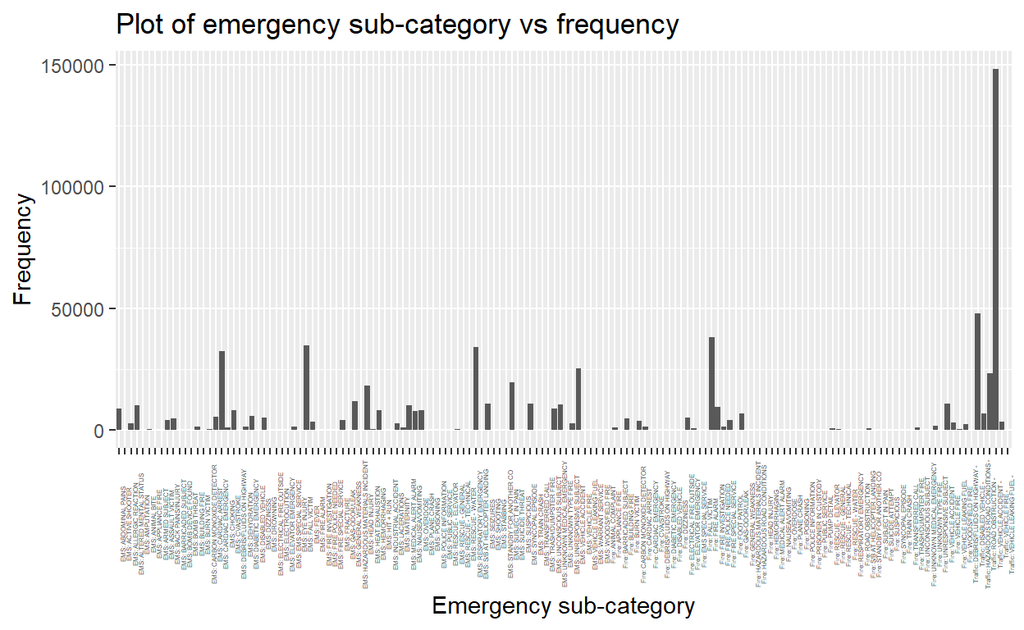

```r
library(ggplot2)
ggplot(emergency_calls_data, aes(x = title)) +
        geom_bar() +
        theme(axis.text.x=element_text(angle=90, size = 3)) +
        labs(x="Emergency sub-category", y="Frequency") +
        ggtitle("Plot of emergency sub-category vs frequency")
```

### Township vs frequency

- Below is a plot of township vs frequency of occurrence grouped by emergency subcategory for a sample of 50 rows.
- This visualization helps us understand what kind of emergencies occur more frequently in every township in Montgomery County. It also helps us compare the number of emergencies that occur across townships. The emergency response team can focus its efforts more on townships that have higher counts of emergencies.
- We can conclude that Lower Merion has the highest number of emergencies from the sample.

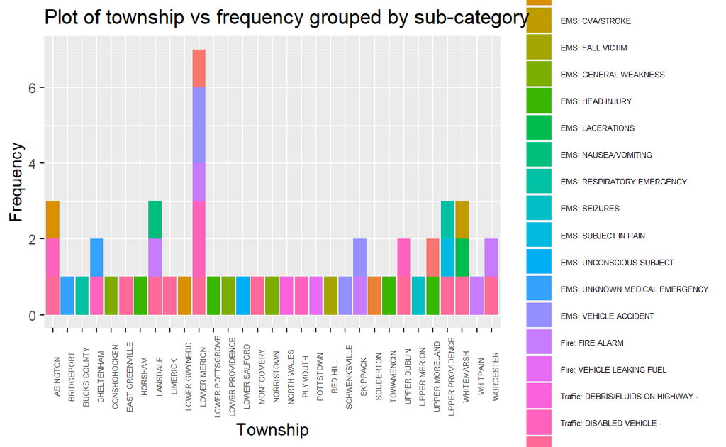

```r
set.seed(1)
emergency_calls_data[sample(nrow(emergency_calls_data), 50), ] %>%
ggplot(aes(x = twp,
           fill = title)) +
  geom_bar(position = "stack") +
  theme(axis.text.x=element_text(angle=90, size = 5), legend.text=element_text(size=5)) +
  labs(x="Township", y="Frequency") +
  ggtitle("Plot of township vs frequency grouped by sub-category")
```

### Emergency call count vs township

Below is a plot of count of various broad categories of emergencies vs township. The dataset has three major predefined categories - EMS, Traffic and Fire. `EMS` includes serious illness or injuries like weakness, head injuries, seizures etc. `Traffic` constitutes vehicle accidents, disabled vehicles etc. `Fire` includes accidents resulting from any kind of fire in a building or outside.

We can see that fire accidents are relatively lesser than EMS or Traffic related emergencies.

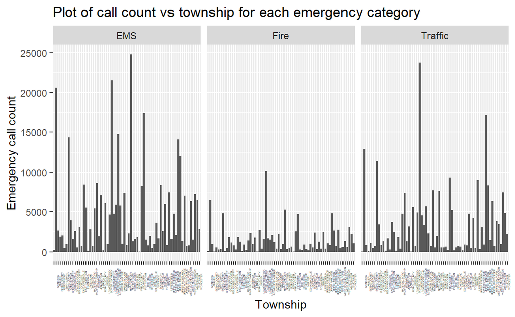

```r
library(stringr)
emergency_calls_data  %>%
mutate(emergency_category=word(title, sep = fixed(":"))) %>%
ggplot(aes(x = twp)) +
  geom_bar() +
  theme(axis.text.x=element_text(angle=90, size = 2.25), legend.text=element_text(size=3)) +
  facet_wrap(vars(emergency_category)) +
  labs(x="Township", y="Emergency call count") +
  ggtitle("Plot of call count vs township for each emergency category")
```

### Emergency call count vs township grouped by emergency category

Below is a barplot of emergency counts vs township grouped by broad emergency categories (EMS, Fire and Traffic)

Lower Merion contributes the highest to the emergency calls in the county followed by Abington and Norristown.

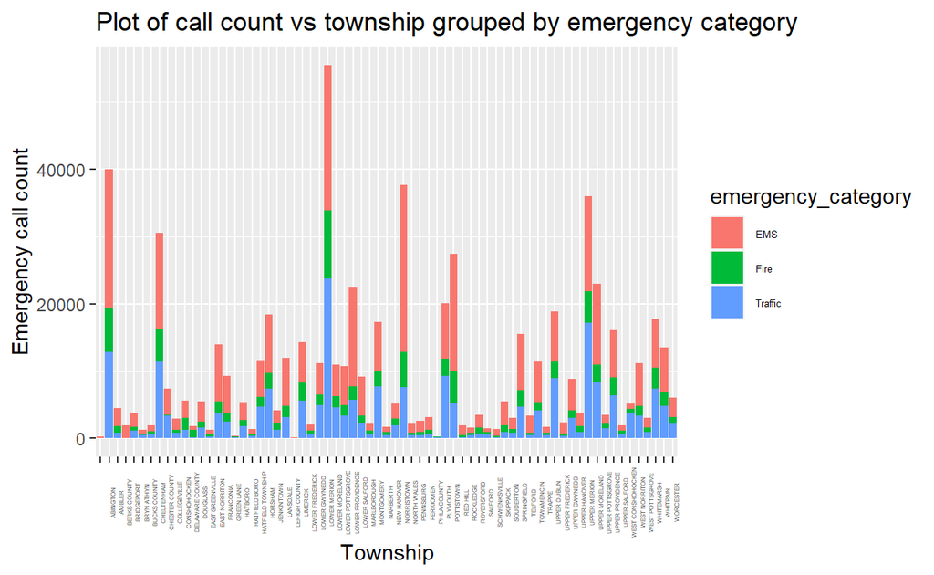

```r
emergency_calls_data  %>%
mutate(emergency_category=word(title, sep = fixed(":"))) %>%
ggplot(aes(x = twp,
           fill = emergency_category)) +
  geom_bar(position = "stack") +
  theme(axis.text.x=element_text(angle=90, size = 3), legend.text=element_text(size=5)) +
  labs(x="Township", y="Emergency call count") +
  ggtitle("Plot of call count vs township grouped by emergency category")
```

### Emergency call count vs year

Below is a plot of emergency call count vs year.

- We can see that 2015 has significantly lower emergencies compared to other years.
- Emergencies are high and nearly the same from 2016 to 2019
- In 2020, the emergency calls have reduced by half from 2019.

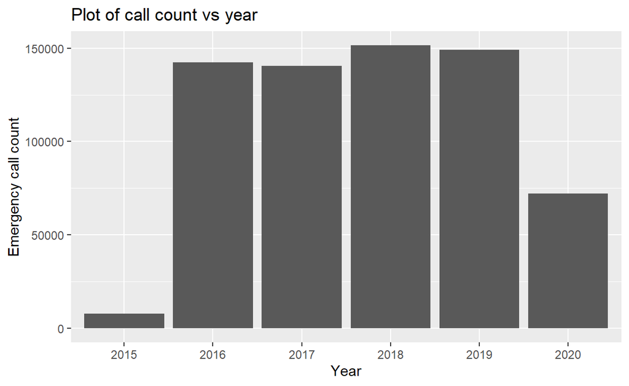

```r
library(stringr)
emergency_calls_data  %>%
mutate(year=format(as.POSIXct(timeStamp, format="%Y-%m-%d %H:%M:%S"), format="%Y")) %>%
ggplot(aes(x = year)) +
  geom_bar() +
  labs(x="Year", y="Emergency call count") +
  ggtitle("Plot of call count vs year")
```

### Vehicle accidents vs year

Since vehicle accidents contribute the most to emergency calls in Montgomery County, here is a plot of vehicle accidents vs year. Vehicle accidents are high during the period from 2016 to 2019

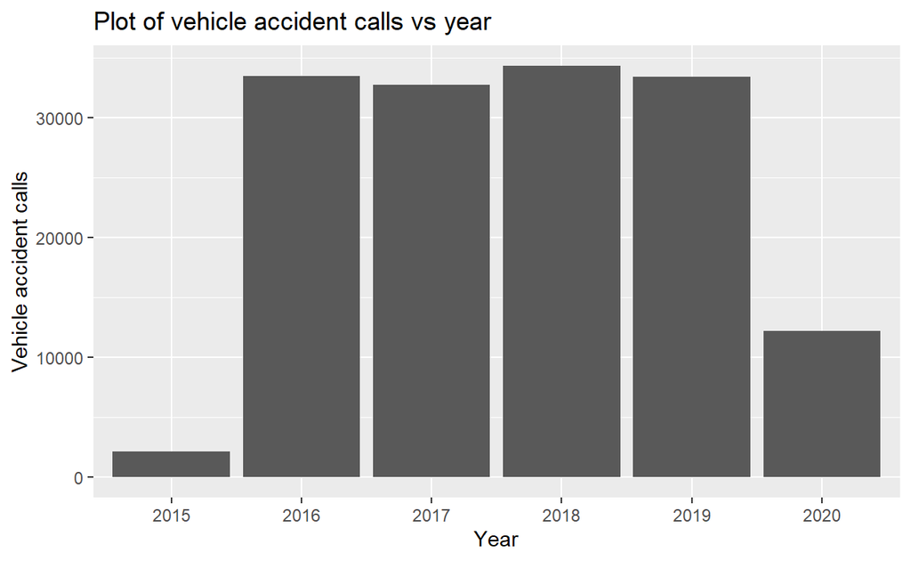

```r
library(stringr)
calls_data <- mutate(emergency_calls_data, year=format(as.POSIXct(timeStamp, format="%Y-%m-%d %H:%M:%S"), format="%Y"))
ggplot(subset(calls_data, title %in% c("Traffic: VEHICLE ACCIDENT -")), aes(x = year)) +
  geom_bar() +
  labs(x="Year", y="Vehicle accident calls") +
  ggtitle("Plot of vehicle accident calls vs year")
```

### Vehicle accident calls vs township

Since vehicle accidents contribute the most to emergency calls in Montgomery County, here is a plot of vehicle accident calls vs township. Lower Merion contributes the most to vehicle accidents followed by Upper Merion.

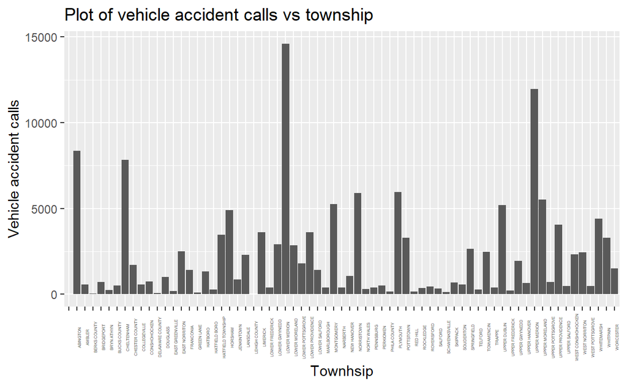

```r
library(stringr)
calls_data <- mutate(emergency_calls_data, year=format(as.POSIXct(timeStamp, format="%Y-%m-%d %H:%M:%S"), format="%Y"))
ggplot(subset(calls_data, title %in% c("Traffic: VEHICLE ACCIDENT -")), aes(x = twp)) +
  geom_bar() +
  theme(axis.text.x=element_text(angle=90, size = 3), legend.text=element_text(size=5)) +
  labs(x="Townhsip", y="Vehicle accident calls") +
  ggtitle("Plot of vehicle accident calls vs township")
```

### Emergency call count vs month

Below is a plot of emergency call count vs month. There is no significant difference in emergency counts amongst the various months.

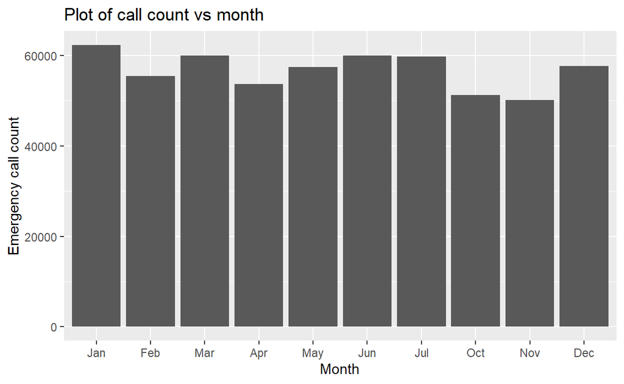

```r
library(stringr)
emergency_calls_data  %>%
mutate(month=ordered(month.abb[strtoi(format(as.POSIXct(timeStamp, format="%Y-%m-%d %H:%M:%S"), format="%m"))], levels=c("Jan", "Feb", "Mar", "Apr", "May", "Jun", "Jul", "Aug", "Sep", "Oct", "Nov", "Dec"))) %>%
filter(!is.na(month)) %>%
ggplot(aes(x = month, na.rm = TRUE)) +
  geom_bar() +
  labs(x="Month", y="Emergency call count") +
  ggtitle("Plot of call count vs month")
```

### Emergency call count vs year grouped by emergency category

Below is a barplot of emergency counts vs year grouped by broad emergency categories (EMS, Fire and Traffic)

- We can see that 2015 has significantly lower emergencies of all types compared to other years.
- There is an increase in all types of emergencies in 2016 and remains nearly the same until 2019.
- The emergency call count reduces in 2020.

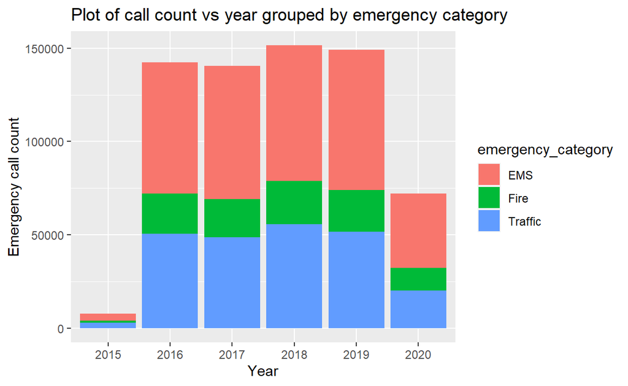

```r
emergency_calls_data  %>%
mutate(emergency_category=word(title, sep = fixed(":")), year=format(as.POSIXct(timeStamp, format="%Y-%m-%d %H:%M:%S"), format="%Y")) %>%
ggplot(aes(x = year,
           fill = emergency_category)) +
  geom_bar(position = "stack") +
  labs(x="Year", y="Emergency call count") +
  ggtitle("Plot of call count vs year grouped by emergency category")
```

### Heatmap of shootings

Below is a heatmap of shootings in various tonwships from 2015-2020. This information can give us insights into the crime scene in various townships.

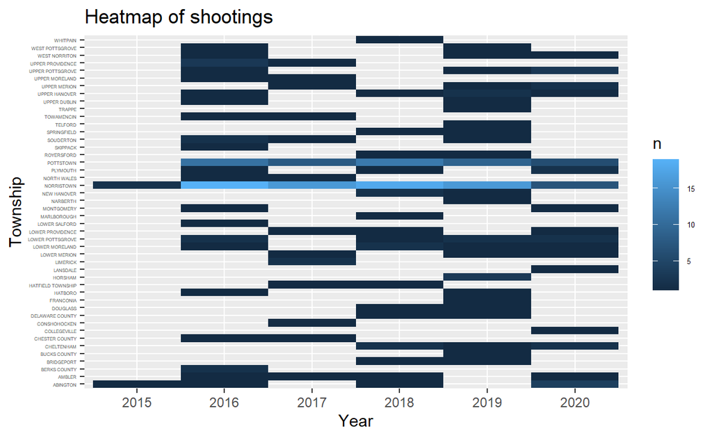

```r
calls_data <- mutate(emergency_calls_data, year=format(as.POSIXct(timeStamp, format="%Y-%m-%d %H:%M:%S"), format="%Y"))
calls_data <- subset(calls_data, title %in% c("EMS: SHOOTING"))
call_count <- count(calls_data, year, twp, .drop=FALSE)
ggplot(call_count, aes(x = year, y = twp,
           fill = n)) +
  labs(x="Year", y="Township") +
  theme(axis.text.y=element_text(size = 3), legend.text=element_text(size=5)) +
  ggtitle("Heatmap of shootings") +
  geom_tile()
```

### Traffic emergency call count vs weekday

- Below is a plot of traffic related emergency calls vs day of the week.
- We can see that the number of traffic related emergencies are higher on Fridays. There could be an increase in the number of vehicles on Fridays with people travelling to other towns, returning home, etc. for the weekend.
- Weekends have lower emergencies compared to weekdays. The reason might be due to higher vehicular movements on weekdays.

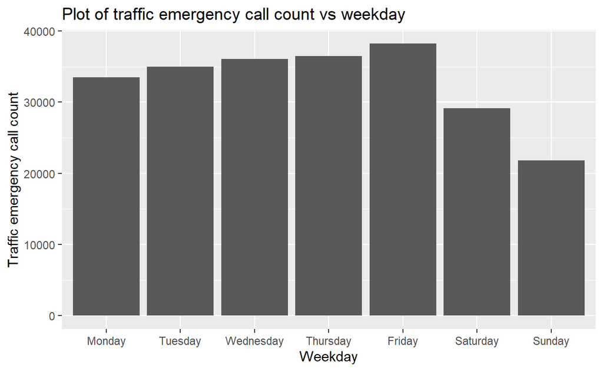

```r
library(stringr)
calls_data <- mutate(emergency_calls_data, day=ordered(weekdays(as.Date(timeStamp)), levels=c("Monday", "Tuesday", "Wednesday", "Thursday",
"Friday", "Saturday", "Sunday")))
calls_data <- filter(calls_data, !is.na(day))
ggplot(subset(calls_data,  grepl('Traffic:', title)), aes(x = day, na.rm = TRUE)) +
  geom_bar() +
  labs(x="Weekday", y="Traffic emergency call count") +
  ggtitle("Plot of traffic emergency call count vs weekday")
```

### Traffic emergency call count vs time of the day

- Below is a plot of traffic related emergency calls vs time of the day.
- Generally the number of traffic related emergencies are higher in the evenings and at night due to higher vehicular movements and also lower visibility when it’s dark.  
  However, we can see that the number of emergencies are higher during the afternoons in our data set. This could be due to incorrect data or there maybe an abnormal pattern that needs to be investigated by the emergency response team.

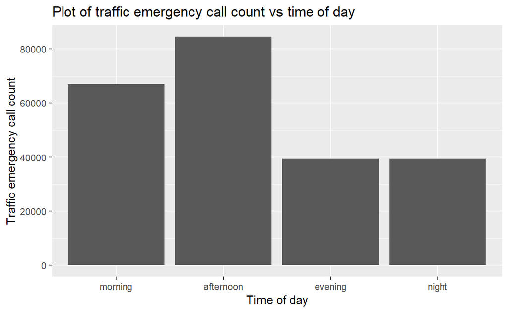

```r
day_time <- as.POSIXct(strptime(c("000000","040000","114500","170000","193000","235959"),
                      "%H%M%S"),"UTC")
labels = c("night","morning","afternoon","evening","night")


calls_data <- mutate(emergency_calls_data, time_of_day=ordered(labels[findInterval(as.POSIXct(strptime(format(strptime(timeStamp, format="%Y-%m-%d %H:%M:%S"), format="%H%M%S"), format="%H%M%S"), "UTC"), day_time)], levels=c("morning", "afternoon", "evening", "night")))
calls_data <- filter(calls_data, !is.na(time_of_day))
ggplot(subset(calls_data,  grepl('Traffic:', title)), aes(x = time_of_day, na.rm = TRUE)) +
  geom_bar() +
  labs(x="Time of day", y="Traffic emergency call count") +
  ggtitle("Plot of traffic emergency call count vs time of day")
```

### Cardiac arrest emergency call count vs time of the day

- Below is a plot of cardiac arrest emergency calls vs time of the day.
- It can be observed that the number of cardiac emergency calls are higher in the morning. This is a scientifically proven fact. During early morning, when blood pressure is higher, the risk of stroke increases.

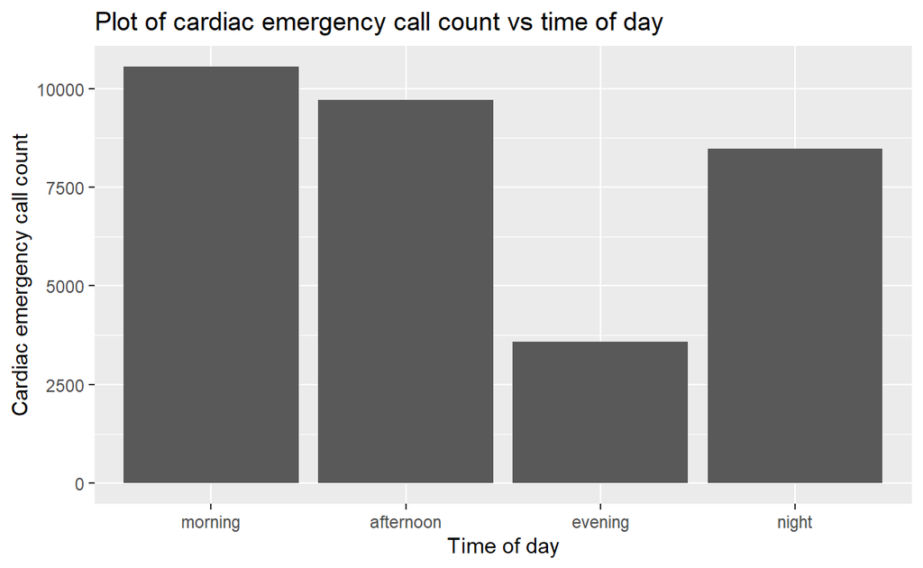

```r
day_time <- as.POSIXct(strptime(c("000000","040000","114500","170000","193000","235959"),
                      "%H%M%S"),"UTC")
labels = c("night","morning","afternoon","evening","night")


calls_data <- mutate(emergency_calls_data, time_of_day=ordered(labels[findInterval(as.POSIXct(strptime(format(strptime(timeStamp, format="%Y-%m-%d %H:%M:%S"), format="%H%M%S"), format="%H%M%S"), "UTC"), day_time)], levels=c("morning", "afternoon", "evening", "night")))
calls_data <- filter(calls_data, !is.na(time_of_day))
ggplot(subset(calls_data,  grepl('EMS: CARDIAC EMERGENCY', title)), aes(x = time_of_day, na.rm = TRUE)) +
  geom_bar() +
  labs(x="Time of day", y="Cardiac emergency call count") +
  ggtitle("Plot of cardiac emergency call count vs time of day")
```

### TODO

What’s missing? What will you add now to deadline?

- Plot graphs to understand how heat exhaustion emergencies vary across the year.
- Find out if there are more such patterns in the data set.
- Explore how frequencies of other types of emergencies vary during the day.
- Fine tune existing plots and add details if required.